# Spatio-temporal Modelling, Lab 9 2024-01-17

# 1 Cokriging

## 1.1 Prepare the data

**sp**

```r
library(gstat)
library(sp)
library(rgdal)
sp.theme(TRUE)
meuse <- readOGR("./data/meuse.gpkg")
meuse.grid <- as(readGDAL("./data/meuse_grid.tif"),"SpatialPixelsDataFrame")
```

```
./data/meuse_grid.tif has GDAL driver GTiff
and has 104 rows and 78 columns
```

```r
names(meuse.grid) <- c("part.a","part.b","dist","soil","ffreq")
meuse.grid$soil <- as.factor(meuse.grid$soil)
meuse.grid$ffreq <- as.factor(meuse.grid$ffreq)
g <- gstat(NULL, "logCd", log(cadmium) ~ 1, meuse)
g <- gstat(g, "logCu", log(copper) ~ 1, meuse)
g <- gstat(g, "logPb", log(lead) ~ 1, meuse)
g <- gstat(g, "logZn", log(zinc) ~ 1, meuse)
g
```

```
data:
logCd : formula = log(cadmium)`~`1 ; data dim = 155 x 13
logCu : formula = log(copper)`~`1 ; data dim = 155 x 13
logPb : formula = log(lead)`~`1 ; data dim = 155 x 13
logZn : formula = log(zinc)`~`1 ; data dim = 155 x 13
```

```r
vm <- variogram(g)
vm.fit <- fit.lmc(vm, g, vgm(1, "Sph", 800, 1))
vm.fit
```

```
data:
logCd : formula = log(cadmium)`~`1 ; data dim = 155 x 13
logCu : formula = log(copper)`~`1 ; data dim = 155 x 13
logPb : formula = log(lead)`~`1 ; data dim = 155 x 13
logZn : formula = log(zinc)`~`1 ; data dim = 155 x 13
variograms:
               model      psill range
logCd[1]         Nug 0.47108736     0
logCd[2]         Sph 1.20070087   800
logCu[1]         Nug 0.06280392     0
logCu[2]         Sph 0.22836610   800
logPb[1]         Nug 0.03259976     0
logPb[2]         Sph 0.49394061   800
logZn[1]         Nug 0.03616482     0
logZn[2]         Sph 0.57792145   800
logCd.logCu[1]   Nug 0.11929270     0
logCd.logCu[2]   Sph 0.47237871   800
logCd.logPb[1]   Nug 0.06317153     0
logCd.logPb[2]   Sph 0.71338924   800
logCu.logPb[1]   Nug 0.02444117     0
logCu.logPb[2]   Sph 0.31242136   800
logCd.logZn[1]   Nug 0.09866415     0
logCd.logZn[2]   Sph 0.79275344   800
logCu.logZn[1]   Nug 0.03519031     0
logCu.logZn[2]   Sph 0.35273813   800
logPb.logZn[1]   Nug 0.02752283     0
logPb.logZn[2]   Sph 0.52261875   800
```

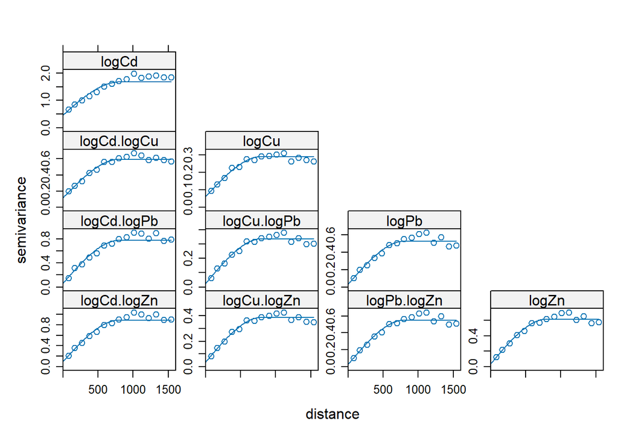

```r
plot(vm, vm.fit)
```

```r
cor(log(as.data.frame(meuse)[c("cadmium", "copper", "lead", "zinc")]))
```

```
          cadmium    copper      lead      zinc
cadmium 1.0000000 0.8363329 0.8124522 0.8624475
copper  0.8363329 1.0000000 0.8428929 0.8971515
lead    0.8124522 0.8428929 1.0000000 0.9671621
zinc    0.8624475 0.8971515 0.9671621 1.0000000
```

**sf/stars**

```r
library(gstat)
library(sf)
library(stars)
library(tmap)
meuse.sf <- st_read("./data/meuse.gpkg")
meuse.grid.stars <- read_stars("./data/meuse_grid.tif")
meuse.grid.stars <- split(meuse.grid.stars, "band")
names(meuse.grid.stars) <- c("part.a","part.b","dist","soil","ffreq")
meuse.grid.stars$soil <- as.factor(meuse.grid.stars$soil)
meuse.grid.stars$ffreq <- as.factor(meuse.grid.stars$ffreq)
bpy.palette=bpy.colors()
g.sf <- gstat(NULL, "logCd", log(cadmium) ~ 1, meuse.sf)
g.sf <- gstat(g.sf, "logCu", log(copper) ~ 1, meuse.sf)
g.sf <- gstat(g.sf, "logPb", log(lead) ~ 1, meuse.sf)
g.sf <- gstat(g.sf, "logZn", log(zinc) ~ 1, meuse.sf)
g.sf
```

```
data:
logCd : formula = log(cadmium)`~`1 ; data dim = 155 x 13
logCu : formula = log(copper)`~`1 ; data dim = 155 x 13
logPb : formula = log(lead)`~`1 ; data dim = 155 x 13
logZn : formula = log(zinc)`~`1 ; data dim = 155 x 13
```

```r
vm.sf <- variogram(g.sf)
vm.fit.sf <- fit.lmc(vm.sf, g.sf, vgm(1, "Sph", 800, 1))
vm.fit.sf
```

```
data:
logCd : formula = log(cadmium)`~`1 ; data dim = 155 x 13
logCu : formula = log(copper)`~`1 ; data dim = 155 x 13
logPb : formula = log(lead)`~`1 ; data dim = 155 x 13
logZn : formula = log(zinc)`~`1 ; data dim = 155 x 13
variograms:
               model      psill range
logCd[1]         Nug 0.47108736     0
logCd[2]         Sph 1.20070087   800
logCu[1]         Nug 0.06280392     0
logCu[2]         Sph 0.22836610   800
logPb[1]         Nug 0.03259976     0
logPb[2]         Sph 0.49394061   800
logZn[1]         Nug 0.03616482     0
logZn[2]         Sph 0.57792145   800
logCd.logCu[1]   Nug 0.11929270     0
logCd.logCu[2]   Sph 0.47237871   800
logCd.logPb[1]   Nug 0.06317153     0
logCd.logPb[2]   Sph 0.71338924   800
logCu.logPb[1]   Nug 0.02444117     0
logCu.logPb[2]   Sph 0.31242136   800
logCd.logZn[1]   Nug 0.09866415     0
logCd.logZn[2]   Sph 0.79275344   800
logCu.logZn[1]   Nug 0.03519031     0
logCu.logZn[2]   Sph 0.35273813   800
logPb.logZn[1]   Nug 0.02752283     0
logPb.logZn[2]   Sph 0.52261875   800
```

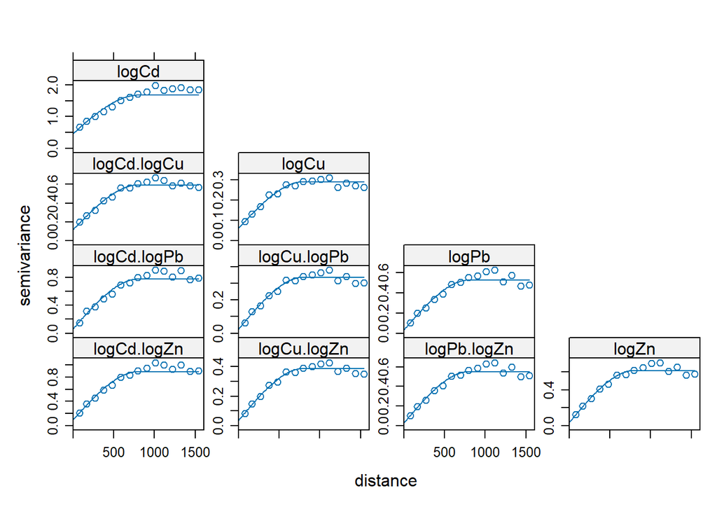

```r
plot(vm.sf, vm.fit.sf)
```

```r
cor(log(as.data.frame(meuse.sf)[c("cadmium", "copper", "lead", "zinc")]))
```

```
          cadmium    copper      lead      zinc
cadmium 1.0000000 0.8363329 0.8124522 0.8624475
copper  0.8363329 1.0000000 0.8428929 0.8971515
lead    0.8124522 0.8428929 1.0000000 0.9671621
zinc    0.8624475 0.8971515 0.9671621 1.0000000
```

## 1.2 Do a cokriging:

**sp**

```r
cokr = predict(vm.fit, meuse.grid)
```

```
Linear Model of Coregionalization found. Good.
[using ordinary cokriging]
```

```r
summary(cokr)
```

```
Object of class SpatialPixelsDataFrame
Coordinates:
     min    max
x 178440 181560
y 329600 333760
Is projected: TRUE
proj4string :
[+proj=sterea +lat_0=52.1561605555556 +lon_0=5.38763888888889
+k=0.9999079 +x_0=155000 +y_0=463000 +ellps=bessel +units=m +no_defs]
Number of points: 3103
Grid attributes:
  cellcentre.offset cellsize cells.dim
x            178460       40        78
y            329620       40       104
Data attributes:
   logCd.pred        logCd.var        logCu.pred      logCu.var
 Min.   :-1.2641   Min.   :0.5669   Min.   :2.879   Min.   :0.07789
 1st Qu.:-0.4181   1st Qu.:0.6914   1st Qu.:3.146   1st Qu.:0.10122
 Median : 0.1953   Median :0.7504   Median :3.364   Median :0.11219
 Mean   : 0.3124   Mean   :0.8012   Mean   :3.448   Mean   :0.12187
 3rd Qu.: 1.0408   3rd Qu.:0.8623   3rd Qu.:3.713   3rd Qu.:0.13356
 Max.   : 2.4473   Max.   :1.4843   Max.   :4.527   Max.   :0.25357
   logPb.pred      logPb.var         logZn.pred      logZn.var
 Min.   :3.637   Min.   :0.05612   Min.   :4.715   Min.   :0.06178
 1st Qu.:4.221   1st Qu.:0.10696   1st Qu.:5.234   1st Qu.:0.12197
 Median :4.550   Median :0.13095   Median :5.568   Median :0.15017
 Mean   :4.650   Mean   :0.15166   Mean   :5.715   Mean   :0.17423
 3rd Qu.:5.100   3rd Qu.:0.17661   3rd Qu.:6.206   3rd Qu.:0.20321
 Max.   :6.295   Max.   :0.44120   Max.   :7.420   Max.   :0.51340
 cov.logCd.logCu  cov.logCd.logPb  cov.logCu.logPb   cov.logCd.logZn
 Min.   :0.1460   Min.   :0.0962   Min.   :0.03767   Min.   :0.1398
 1st Qu.:0.1948   1st Qu.:0.1703   1st Qu.:0.07065   1st Qu.:0.2211
 Median :0.2178   Median :0.2050   Median :0.08580   Median :0.2598
 Mean   :0.2373   Mean   :0.2348   Mean   :0.09878   Mean   :0.2929
 3rd Qu.:0.2612   3rd Qu.:0.2706   3rd Qu.:0.11445   3rd Qu.:0.3331
 Max.   :0.5113   Max.   :0.6528   Max.   :0.28212   Max.   :0.7557
 cov.logCu.logZn   cov.logPb.logZn
 Min.   :0.05192   Min.   :0.04959
 1st Qu.:0.08852   1st Qu.:0.10441
 Median :0.10566   Median :0.12977
 Mean   :0.12037   Mean   :0.15157
 3rd Qu.:0.13809   3rd Qu.:0.17777
 Max.   :0.32687   Max.   :0.45864
```

**sf/stars**

```r
cokr.stars = predict(vm.fit.sf, meuse.grid.stars)
```

```
Linear Model of Coregionalization found. Good.
[using ordinary cokriging]
```

```r
summary(cokr.stars)
```

```
                Length Class  Mode
logCd.pred      8112   -none- numeric
logCd.var       8112   -none- numeric
logCu.pred      8112   -none- numeric
logCu.var       8112   -none- numeric
logPb.pred      8112   -none- numeric
logPb.var       8112   -none- numeric
logZn.pred      8112   -none- numeric
logZn.var       8112   -none- numeric
cov.logCd.logCu 8112   -none- numeric
cov.logCd.logPb 8112   -none- numeric
cov.logCu.logPb 8112   -none- numeric
cov.logCd.logZn 8112   -none- numeric
cov.logCu.logZn 8112   -none- numeric
cov.logPb.logZn 8112   -none- numeric
```

#### *Exercise 1*

**Exercise 1**

*Explain in language (without equations) what the variables in the resulting object represent, and how they were computed!*

**Solution**

Cokriging in gstat gives predictions and kriging variance for the single variables (e.g. `logCd.pred` and `logCd.var` for Cadmium) as well as the covriances of the prediction errors of the variables at the sampling points (e.g. `cov.logCd.logCu` for covariance of the prediction error between Cadmium and Copper). The predictions and variances are calculated using the spatial autocorrelation and cross correlation (derived from the cross covariograms).

#### *Exercise 2*

**Exercise 2**

*Explain why all the prediction error covariances are positive!*

**Solution**

The prediction error increases with the distance between points for all variables. Thus, there is a positive correlation and positive covariance between the prediction errors of all variables.

We want to compute an index of toxicity of the soil, where the different heavy metals are weighted according to their toxicity. The index is computed as

$$I=100\log{Cd}+10logPb+logZn$$

where $logCd$, $logPb$ and $logZn$ are the log-predictions as obtained above.

#### *Exercise 3*

**Exercise 3**

*Give the R commands to compute this index and to show a map of it. Also give the commands to compute the standard error of the index, taking the error covariances into account.*

**Solution**

To calculate the index you can simply insert the prediction values into the index equation and create a new index variable.

**sp**

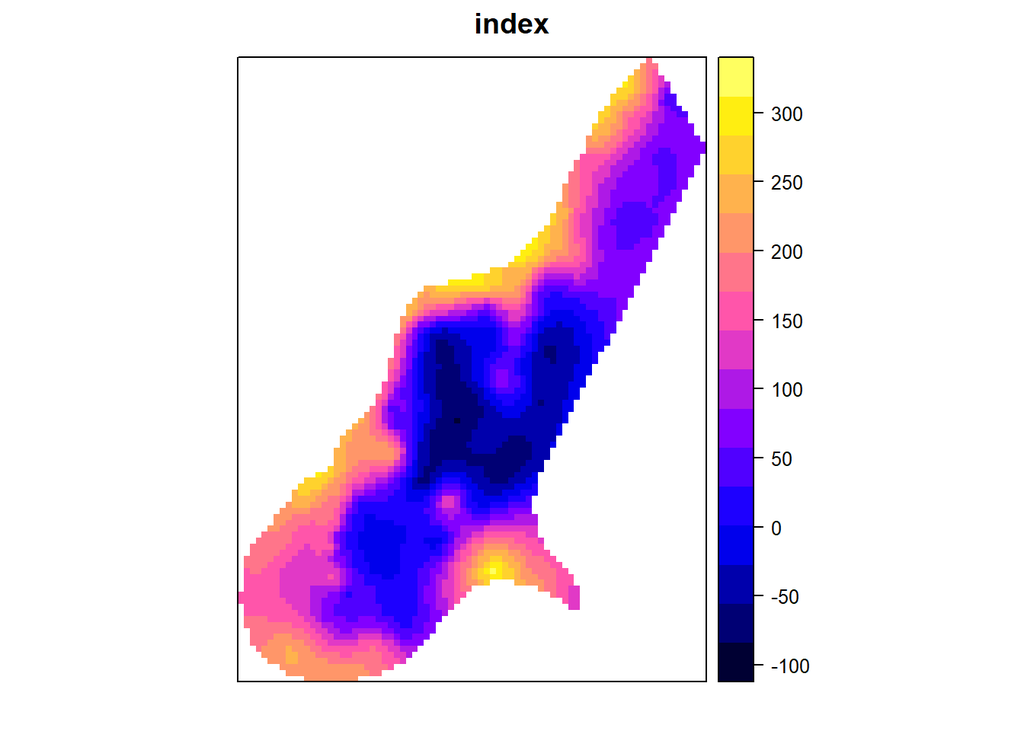

```r
cokr$index = 100 * cokr$logCd.pred + 10 * cokr$logPb.pred + cokr$logZn.pred
spplot(cokr, "index", main = "index")
```

**sf/stars**

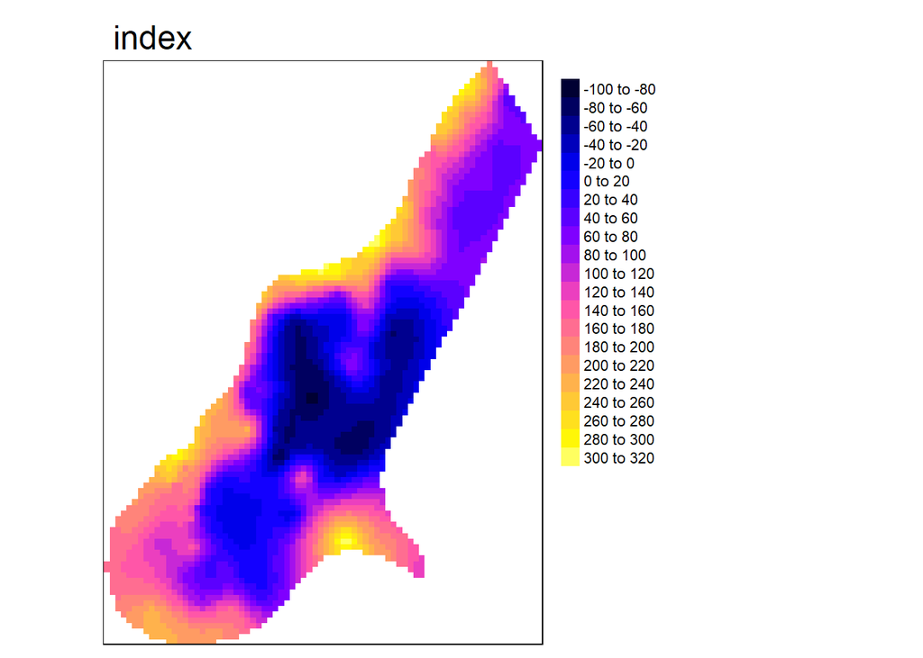

```r
cokr.stars$index = 100 * cokr.stars$logCd.pred + 10 * cokr.stars$logPb.pred + cokr.stars$logZn.pred
tm_shape(cokr.stars) +
  tm_raster("index", palette = bpy.palette, n=20, title = "",midpoint = NA) +
  tm_layout(main.title = "index", legend.outside = TRUE)
```

To compute the standard error of the index you can calculate the kriging variances using the formula for the variance of the sum of random variables:

$$Var(\sum_{i=1}^n X_i) = \sum_{i=1}^n Var(X_i)+2*\sum_{i=1}^{n-1} \sum_{j=i+1}^n Cov(X_i,X_j)$$

**sp**

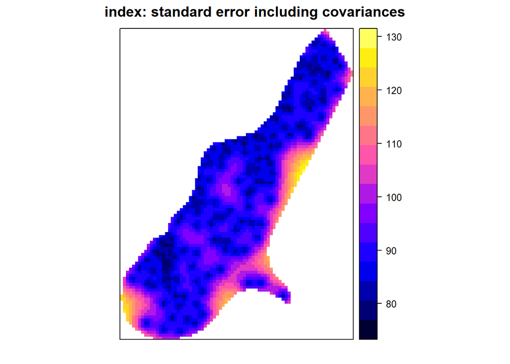

```r
cokr$index.var = 100^2 * cokr$logCd.var + 10^2 * cokr$logPb.var + cokr$logZn.var +
    2 * (100 * 10 * cokr$cov.logCd.logPb + 100 * cokr$cov.logCd.logZn + 10 *
        cokr$cov.logPb.logZn)
cokr$index.se = sqrt(cokr$index.var)
spplot(cokr, "index.se", main = "index: standard error including covariances")
```

**sf/stars**

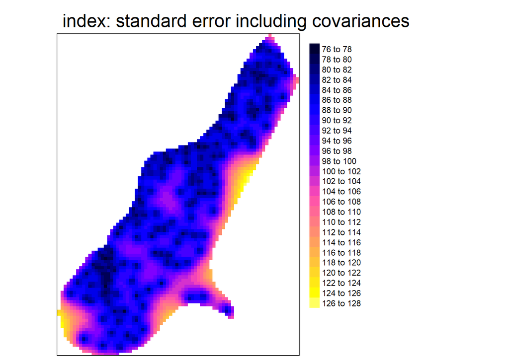

```r
cokr.stars$index.var = 100^2 * cokr.stars$logCd.var + 10^2 * cokr.stars$logPb.var + cokr.stars$logZn.var +
    2 * (100 * 10 * cokr.stars$cov.logCd.logPb + 100 * cokr.stars$cov.logCd.logZn + 10 *
        cokr.stars$cov.logPb.logZn)
cokr.stars$index.se = sqrt(cokr.stars$index.var)
tm_shape(cokr.stars) +
  tm_raster("index.se", palette = bpy.palette, n=20, title = "",midpoint = NA) +
  tm_layout(main.title = "index: standard error including covariances", legend.outside = TRUE)
```

#### *Exercise 4*

**Exercise 4**

*How much does the standard error of this toxicity index change as a result of taking the covariances into account, as opposed to ignoring them?*

**Solution**

To answer this you can calculate and plot the standard error without taking covariances into account:

**sp**

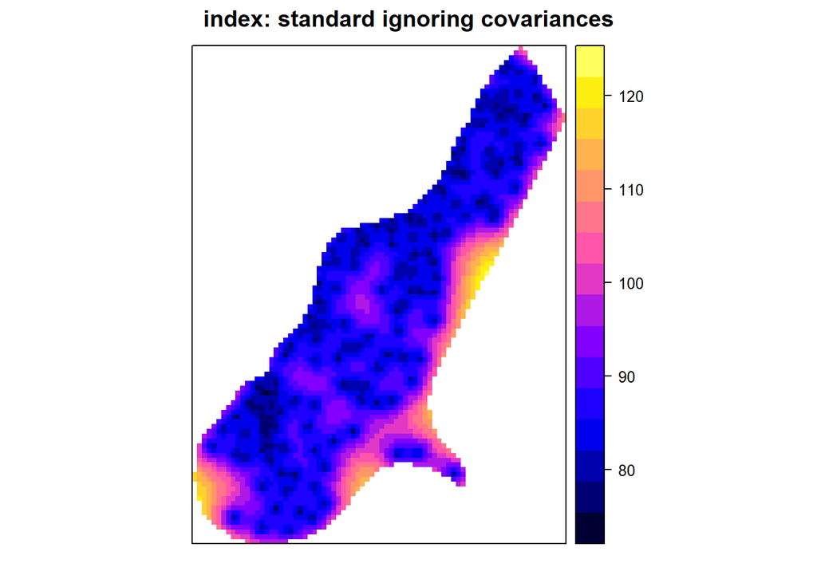

```r
cokr$index.varu = 100^2 * cokr$logCd.var + 10^2 * cokr$logPb.var + cokr$logZn.var
cokr$index.seu = sqrt(cokr$index.varu)
spplot(cokr, "index.seu", main = "index: standard ignoring covariances")
```

**sf/stars**

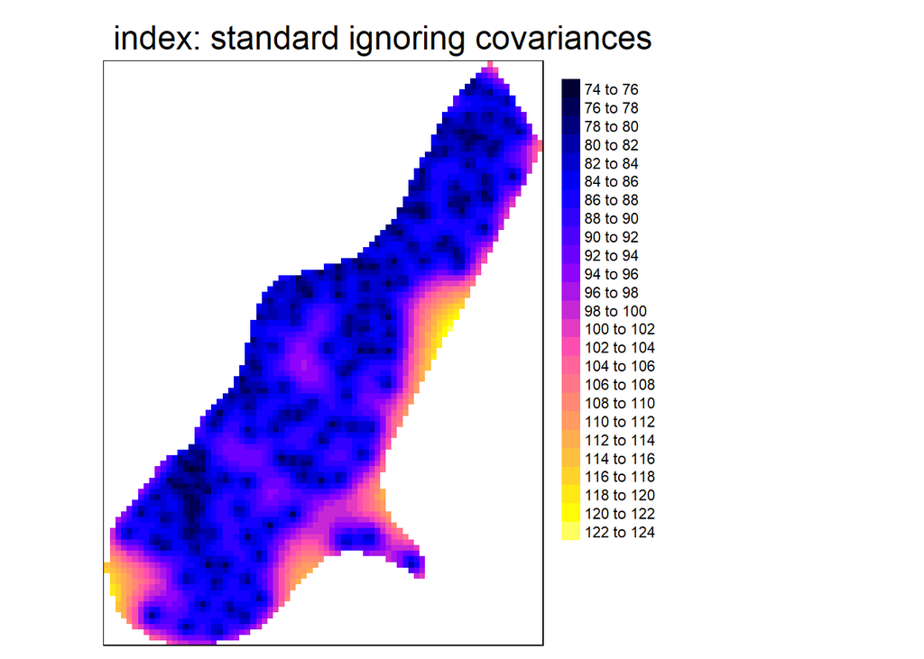

```r
cokr.stars$index.varu = 100^2 * cokr.stars$logCd.var + 10^2 * cokr.stars$logPb.var + cokr.stars$logZn.var
cokr.stars$index.seu = sqrt(cokr.stars$index.varu)
tm_shape(cokr.stars) +
  tm_raster("index.seu", palette = bpy.palette, n=20, title = "",midpoint = NA) +
  tm_layout(main.title = "index: standard ignoring covariances", legend.outside = TRUE)
```

As the differences in this map are difficult to determine, you can also look at the numbers:

**sp**

```r
summary(cokr$index.seu)
```

```
   Min. 1st Qu.  Median    Mean 3rd Qu.    Max.
  75.33   83.22   86.70   89.19   92.96  122.01
```

```r
summary(cokr$index.se)
```

```
   Min. 1st Qu.  Median    Mean 3rd Qu.    Max.
  76.82   85.51   89.34   92.04   96.22  127.88
```

```r
sum(cokr$index.seu)
```

```
[1] 276758
```

```r
sum(cokr$index.se)
```

```
[1] 285606.7
```

**sf/stars**

```r
cokr.stars["index.seu"]
```

```
stars object with 2 dimensions and 1 attribute
attribute(s):
               Min.  1st Qu.   Median     Mean  3rd Qu.     Max. NA's
index.seu  75.33296 83.21534 86.70311 89.19047 92.95514 122.0135 5009
dimension(s):
  from  to offset delta              refsys x/y
x    1  78 178440    40 Amersfoort / RD New [x]
y    1 104 333760   -40 Amersfoort / RD New [y]
```

```r
cokr.stars["index.se"]
```

```
stars object with 2 dimensions and 1 attribute
attribute(s):
             Min.  1st Qu.   Median     Mean  3rd Qu.     Max. NA's
index.se  76.8238 85.50526 89.33765 92.04213 96.21852 127.8794 5009
dimension(s):
  from  to offset delta              refsys x/y
x    1  78 178440    40 Amersfoort / RD New [x]
y    1 104 333760   -40 Amersfoort / RD New [y]
```

```r
sum(cokr.stars$index.seu,na.rm = T)
```

```
[1] 276758
```

```r
sum(cokr.stars$index.se, na.rm = T)
```

```
[1] 285606.7
```

As you can see, the prediction error without using spatial covariances is slightly lower than with using them.

## 1.3 Cokriging: the undersampled case

Take a subsample of `zinc`, called `meuse1`:

**sp**

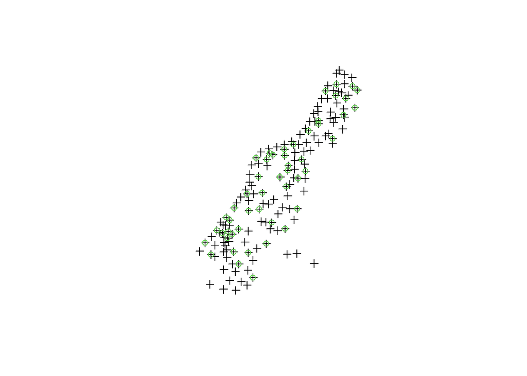

```r
set.seed(1331)
sam = sample(155)
sam1 = sam[1:50]
sam2 = sam[-(1:50)]
meuse1 = meuse[sam1, ]
meuse2 = meuse[sam2, ]
plot(meuse, col = 1, pch = 3)
plot(meuse1, col = 3, pch = 1, add = TRUE)
```

**sf/stars**

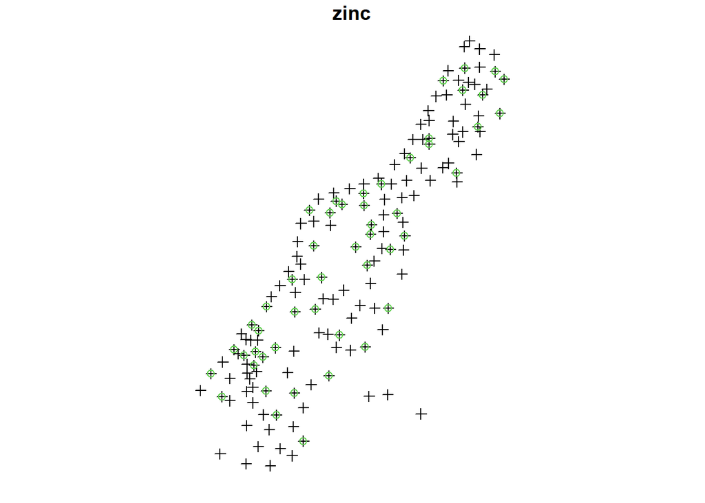

```r
set.seed(1331)
sam = sample(155)
sam1 = sam[1:50]
sam2 = sam[-(1:50)]
meuse1.sf = meuse.sf[sam1, ]
meuse2.sf = meuse.sf[sam2, ]
plot(meuse.sf["zinc"], col = 1, pch = 3,reset=FALSE)
plot(meuse1.sf["zinc"], col = 3, pch = 1, add = TRUE)
```

create a multivariate object with subsample of `zinc`, and full sample of `lead`:

**sp**

```r
g = gstat(NULL, "logZinc", log(zinc) ~ 1, meuse1, set = list(nocheck = 1))
g = gstat(g, "logLead", log(lead) ~ 1, meuse, set = list(nocheck = 1))
v12 = variogram(g)
v12 = subset(v12, dist != 0)  # remove 0 distances for fitting
v12.fit = fit.lmc(v12, g, vgm(1, "Sph", 900, 1))
v12.fit
```

```
data:
logZinc : formula = log(zinc)`~`1 ; data dim = 50 x 13
logLead : formula = log(lead)`~`1 ; data dim = 155 x 13
variograms:
                   model      psill range
logZinc[1]           Nug 0.13766910     0
logZinc[2]           Sph 0.50564130   900
logLead[1]           Nug 0.04562508     0
logLead[2]           Sph 0.50822237   900
logZinc.logLead[1]   Nug 0.07925379     0
logZinc.logLead[2]   Sph 0.50693019   900
set nocheck = 1;
```

```r
class(v12.fit)
```

```
[1] "gstat" "list"
```

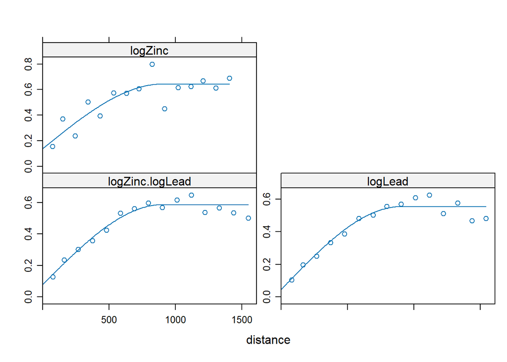

```r
plot(v12, v12.fit)
```

**sf/stars**

```r
g.sf = gstat(NULL, "logZinc", log(zinc) ~ 1, meuse1.sf, set = list(nocheck = 1))
g.sf = gstat(g.sf, "logLead", log(lead) ~ 1, meuse.sf, set = list(nocheck = 1))
v12.sf = variogram(g.sf)
v12.sf = subset(v12.sf, dist != 0)  # remove 0 distances for fitting
v12.fit.sf = fit.lmc(v12.sf, g.sf, vgm(1, "Sph", 900, 1))
v12.fit.sf
```

```
data:
logZinc : formula = log(zinc)`~`1 ; data dim = 50 x 13
logLead : formula = log(lead)`~`1 ; data dim = 155 x 13
variograms:
                   model      psill range
logZinc[1]           Nug 0.13766910     0
logZinc[2]           Sph 0.50564130   900
logLead[1]           Nug 0.04562508     0
logLead[2]           Sph 0.50822237   900
logZinc.logLead[1]   Nug 0.07925379     0
logZinc.logLead[2]   Sph 0.50693019   900
set nocheck = 1;
```

```r
class(v12.fit.sf)
```

```
[1] "gstat" "list"
```

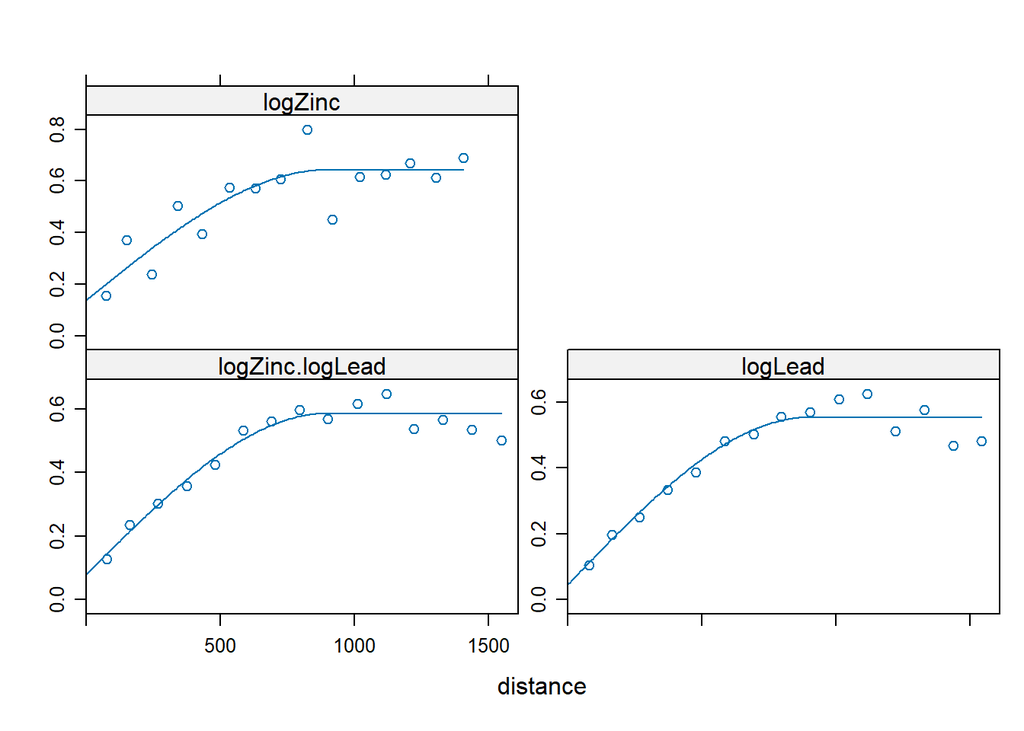

```r
plot(v12.sf, v12.fit.sf)
```

cokrige:

**sp**

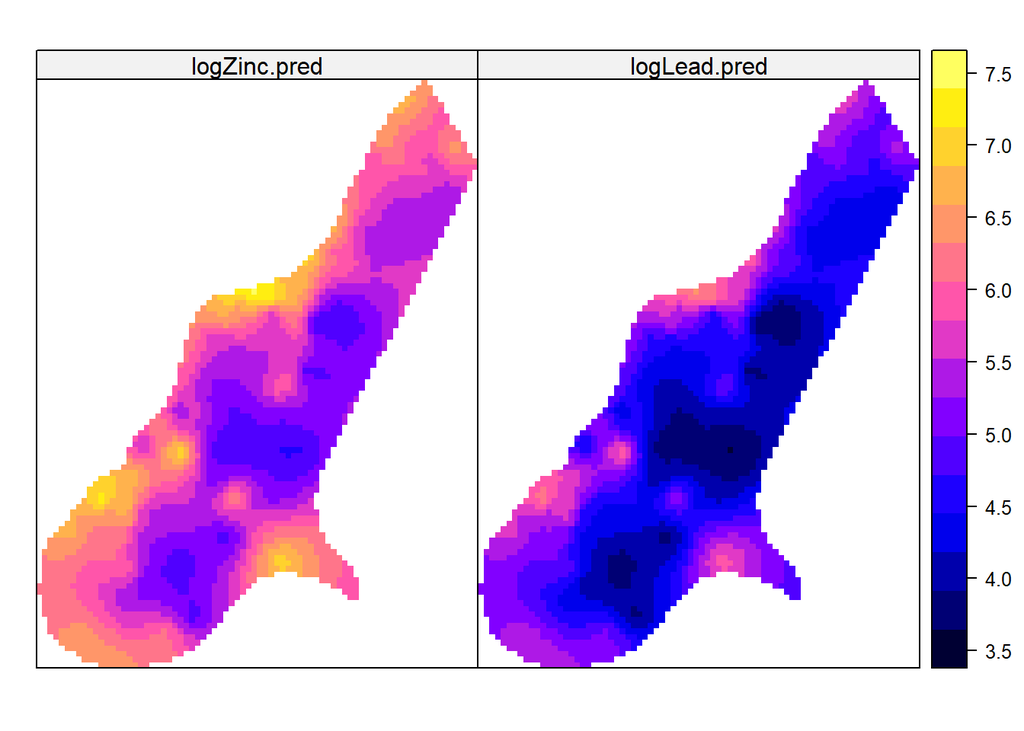

```r
v12.pr = predict(v12.fit, meuse.grid)
spplot(v12.pr, c("logZinc.pred", "logLead.pred"))
```

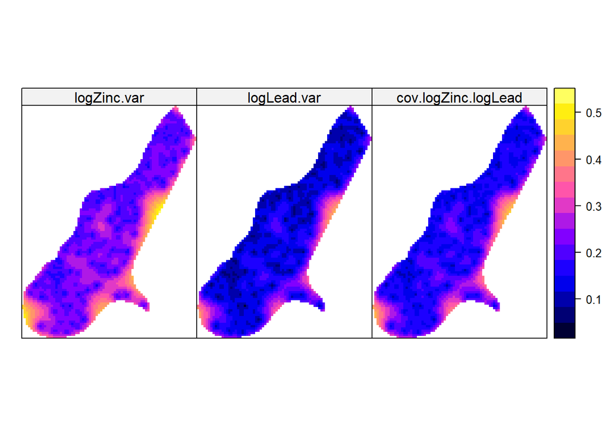

```r
spplot(v12.pr, c("logZinc.var", "logLead.var", "cov.logZinc.logLead"))
```

**sf/stars**

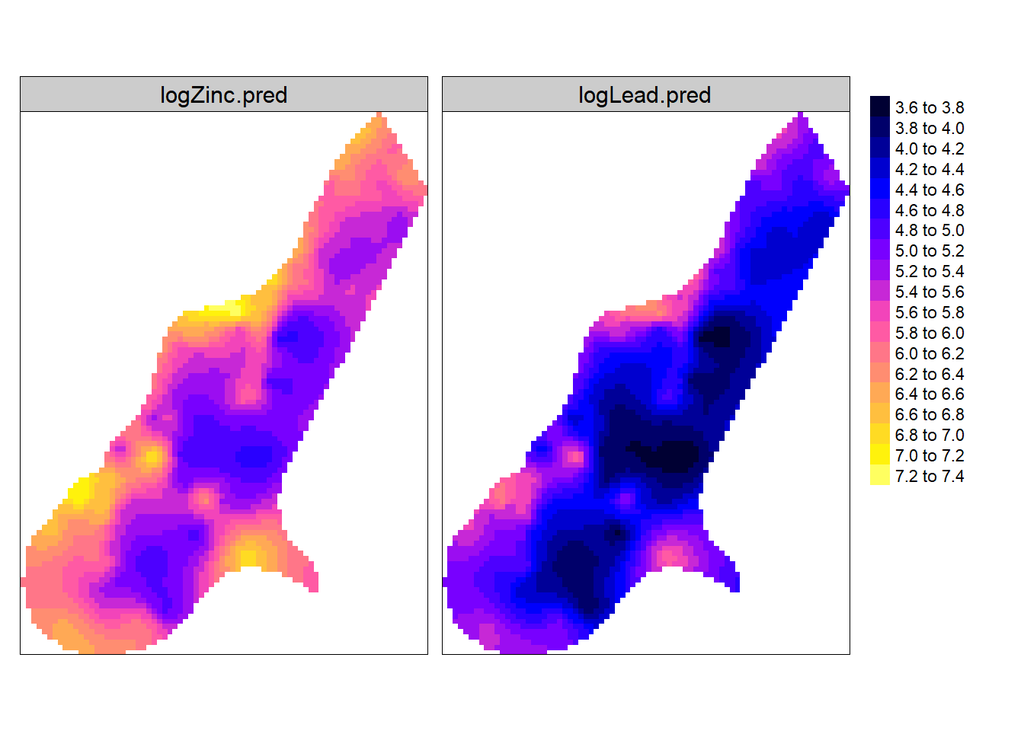

```r
v12.pr.stars = predict(v12.fit.sf, meuse.grid.stars)
tm_shape(v12.pr.stars) +
  tm_raster(c("logZinc.pred", "logLead.pred"), n=20, title = "", palette = bpy.palette) +
  tm_facets(free.scales=FALSE) +
  tm_layout(legend.outside.size = 0.15, panel.labels=c("logZinc.pred", "logLead.pred"))
```

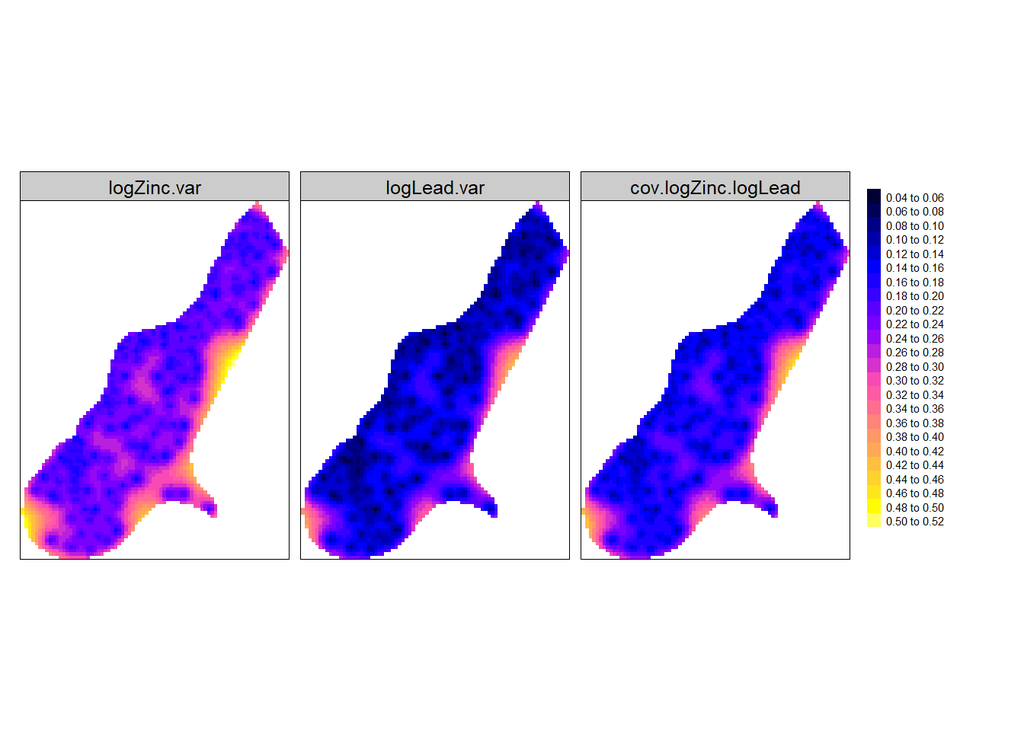

```r
tm_shape(v12.pr.stars) +
  tm_raster(c("logZinc.var", "logLead.var", "cov.logZinc.logLead"), n=20, title = "", palette = bpy.palette) +
  tm_facets(free.scales=FALSE) +
  tm_layout(legend.outside.size = 0.15, panel.labels=c("logZinc.var", "logLead.var", "cov.logZinc.logLead"))
```

compare the differences of kriging the 50 observations of `zinc` with the cokriging from 50 zinc and 155 lead observations:

**sp**

```r
v12.fit[1]
```

```
data:
logZinc : formula = log(zinc)`~`1 ; data dim = 50 x 13
variograms:
           model     psill range
logZinc[1]   Nug 0.1376691     0
logZinc[2]   Sph 0.5056413   900
set nocheck = 1;
```

```r
v1.pr = predict(v12.fit[1], meuse.grid)
```

```
[using ordinary kriging]
```

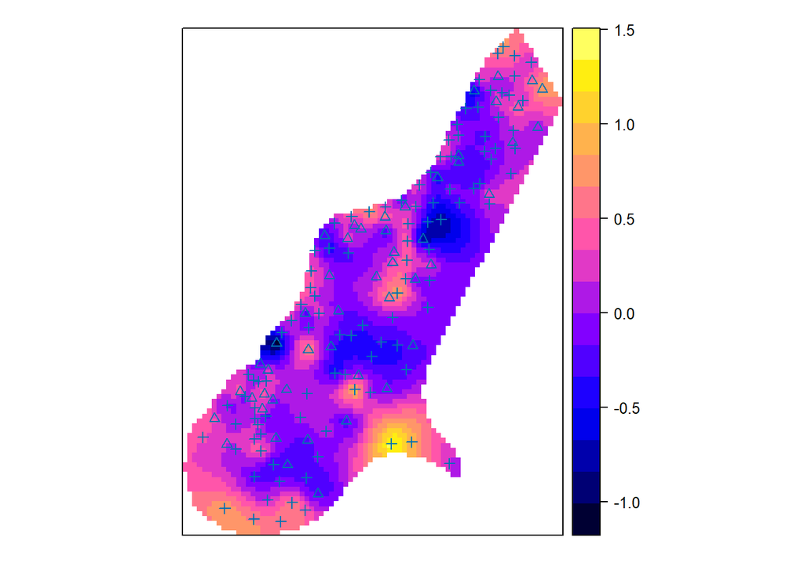

```r
lt = list(list("sp.points", meuse2, pch = 3), list("sp.points", meuse1, pch = 2))
v12.pr$diffpr = v12.pr$logZinc.pred - v1.pr$logZinc.pred
spplot(v12.pr["diffpr"], sp.layout = lt)
```

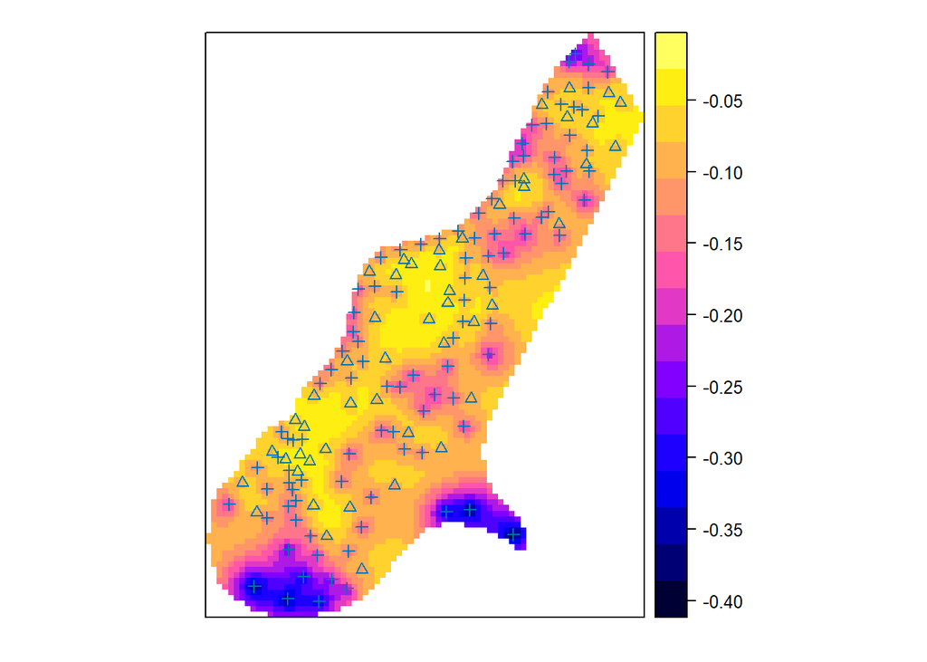

```r
v12.pr$diffse = sqrt(v12.pr$logZinc.var) - sqrt(v1.pr$logZinc.var)
spplot(v12.pr["diffse"], sp.layout = lt)
```

**sf/stars**

```r
v12.fit.sf[1]
```

```
data:
logZinc : formula = log(zinc)`~`1 ; data dim = 50 x 13
variograms:
           model     psill range
logZinc[1]   Nug 0.1376691     0
logZinc[2]   Sph 0.5056413   900
set nocheck = 1;
```

```r
v1.pr.stars = predict(v12.fit.sf[1], meuse.grid.stars)
```

```
[using ordinary kriging]
```

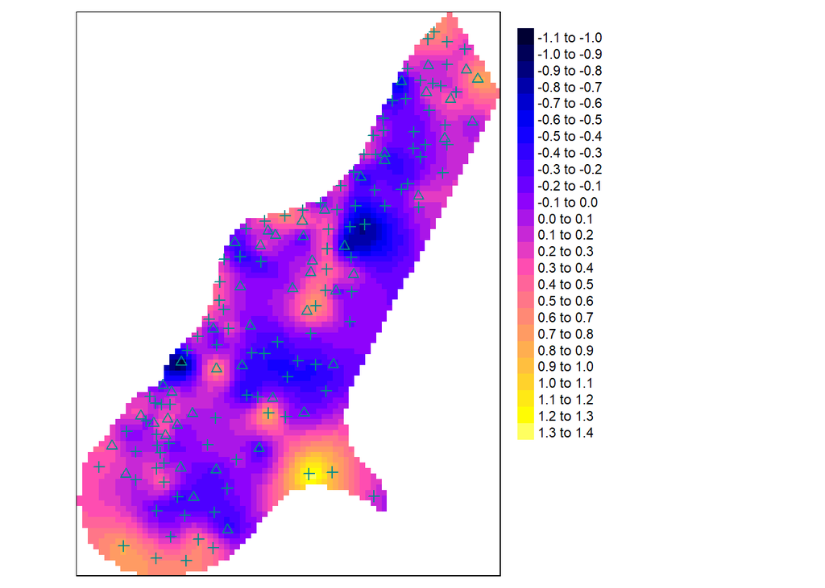

```r
v12.pr.stars$diffpr = v12.pr.stars$logZinc.pred - v1.pr.stars$logZinc.pred
tm_shape(v12.pr.stars) +
  tm_raster("diffpr", title = "",palette = bpy.palette, n=20, midpoint = NA) +
  tm_shape(meuse2.sf) + tm_symbols(size = 0.2,  shape = 3, col = "cyan4") +
  tm_shape(meuse1.sf) + tm_symbols(size = 0.2, shape = 2, col = "cyan4") +
  tm_layout(legend.outside = TRUE)
```

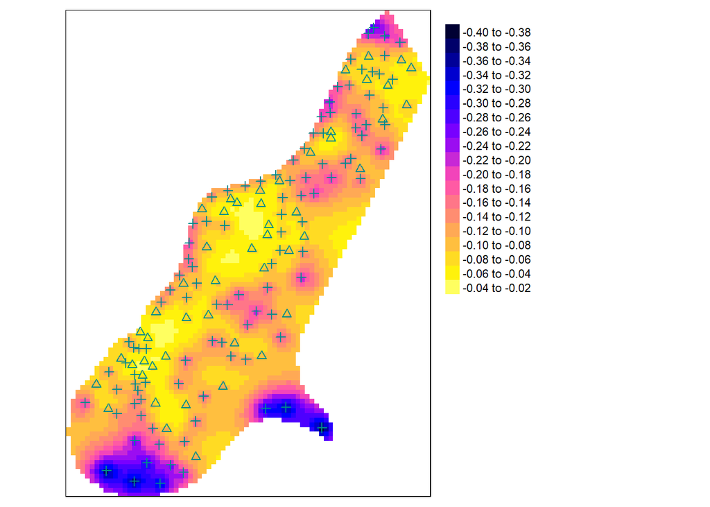

```r
v12.pr.stars$diffse = sqrt(v12.pr.stars$logZinc.var) - sqrt(v1.pr.stars$logZinc.var)
tm_shape(v12.pr.stars) +
  tm_raster("diffse", title = "",palette = bpy.palette, n=20, midpoint = NA) +
  tm_shape(meuse2.sf) + tm_symbols(size = 0.2,  shape = 3, col = "cyan4") +
  tm_shape(meuse1.sf) + tm_symbols(size = 0.2, shape = 2, col = "cyan4") +
  tm_layout(legend.outside = TRUE)
```

#### *Exercise 5*

**Exercise 5**

*Why are the standard errors smaller in the cokriging case?*

**Solution**

The standard errors are smaller because zinc and lead are strongly correlated. Therefore, the measurements of lead increase the accuracy of the estimation.

# 2 Kriging errors and confidence intervals

Given that we are not certain about zinc levels at locations where we did not measure it (i.e., interpolated grid cells) we can classify them according to their approximate confidence intervals, formed by using mean and standard error (here: on the log scale).

**sp**

```r
# Ordinary Kriging log(zinc)
m <- vgm(0.59, "Sph", 874, 0.04)
# ordinary kriging:
lzn.ok <- krige(log(zinc) ~ 1, meuse, meuse.grid, model = m)
```

```
[using ordinary kriging]
```

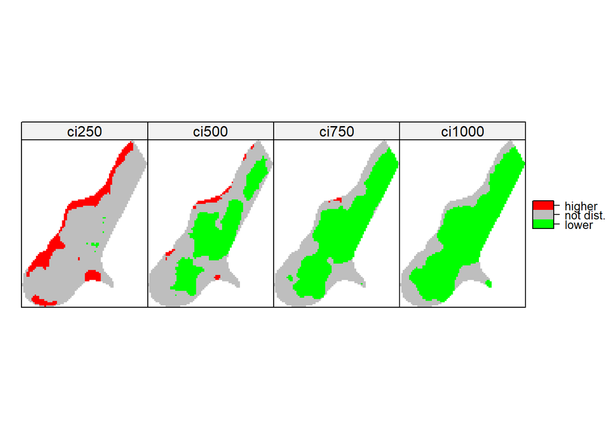

```r
ci = function(cutoff, mean, var, alpha = 0.05) {
    p = 1 - pnorm(cutoff, mean, sqrt(var))  #$
    f = ifelse(p < alpha/2, "lower", ifelse(p < (1 - alpha/2), "not dist.",
        "higher"))
    factor(f, levels = c("lower", "not dist.", "higher"))
}
lzn.ok$ci250 = ci(log(250), lzn.ok$var1.pred, lzn.ok$var1.var)
lzn.ok$ci500 = ci(log(500), lzn.ok$var1.pred, lzn.ok$var1.var)
lzn.ok$ci750 = ci(log(750), lzn.ok$var1.pred, lzn.ok$var1.var)
lzn.ok$ci1000 = ci(log(1000), lzn.ok$var1.pred, lzn.ok$var1.var)
spplot(lzn.ok, c("ci250", "ci500", "ci750", "ci1000"), col.regions = c("green",
    "grey", "red"))
```

**sf/stars**

```r
# Ordinary Kriging log(zinc)
m <- vgm(0.59, "Sph", 874, 0.04)
# ordinary kriging:
lzn.ok.stars <- krige(log(zinc) ~ 1, meuse.sf, meuse.grid.stars, model = m)
```

```
[using ordinary kriging]
```

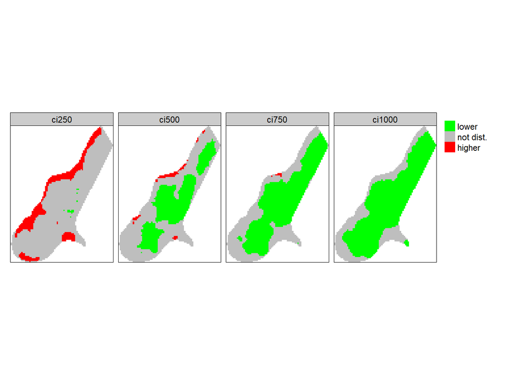

```r
ci = function(cutoff, mean, var, alpha = 0.05) {
    p = 1 - pnorm(cutoff, mean, sqrt(var))  #$
    f = ifelse(p < alpha/2, "lower", ifelse(p < (1 - alpha/2), "not dist.",
        "higher"))
    factor(f, levels = c("lower", "not dist.", "higher"))
}
lzn.ok.stars$ci250 = ci(log(250), lzn.ok.stars$var1.pred, lzn.ok.stars$var1.var)
lzn.ok.stars$ci500 = ci(log(500), lzn.ok.stars$var1.pred, lzn.ok.stars$var1.var)
lzn.ok.stars$ci750 = ci(log(750), lzn.ok.stars$var1.pred, lzn.ok.stars$var1.var)
lzn.ok.stars$ci1000 = ci(log(1000), lzn.ok.stars$var1.pred, lzn.ok.stars$var1.var)
tm_shape(lzn.ok.stars) +
  tm_raster(c("ci250", "ci500", "ci750", "ci1000"), n=3, title = "", palette = c("green",
    "grey", "red") ) +
  tm_facets(free.scales=FALSE, nrow = 1) +
  tm_layout(legend.outside.size = 0.15, panel.labels=c("ci250", "ci500", "ci750", "ci1000"))
```

#### *Exercise 6*

**Exercise 6**

*For which fraction of the total area is the zinc concentration lower than 500 ppm, with 95 percent confidence? Give the number of grid cells for which this is the case, and describe where in the area they are situated.*

**Solution**

You only need the `summary()` command:

**sp**

```r
summary(lzn.ok$ci500)
```

```
    lower not dist.    higher
     1245      1772        86
```

**sf/stars**

```r
summary(lzn.ok.stars$ci500)
```

```
    lower not dist.    higher      NA's
     1245      1772        86      5009
```

The values with low predictions are in larger distances to the river.

For a single threshold, we can vary the confidence level by specifying `alpha`:

**sp**

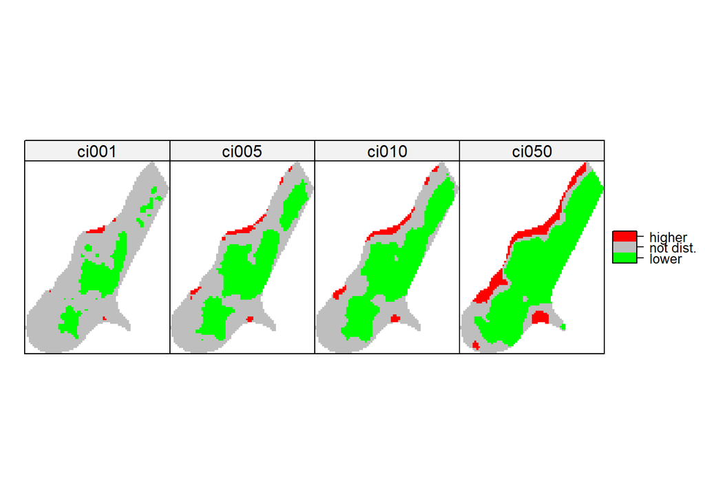

```r
lzn.ok$ci001 = ci(log(500), lzn.ok$var1.pred, lzn.ok$var1.var, 0.01)
lzn.ok$ci005 = ci(log(500), lzn.ok$var1.pred, lzn.ok$var1.var, 0.05)
lzn.ok$ci010 = ci(log(500), lzn.ok$var1.pred, lzn.ok$var1.var, 0.1)
lzn.ok$ci050 = ci(log(500), lzn.ok$var1.pred, lzn.ok$var1.var, 0.5)
spplot(lzn.ok, c("ci001", "ci005", "ci010", "ci050"), col.regions = c("green",
    "grey", "red"))
```

**sf/stars**

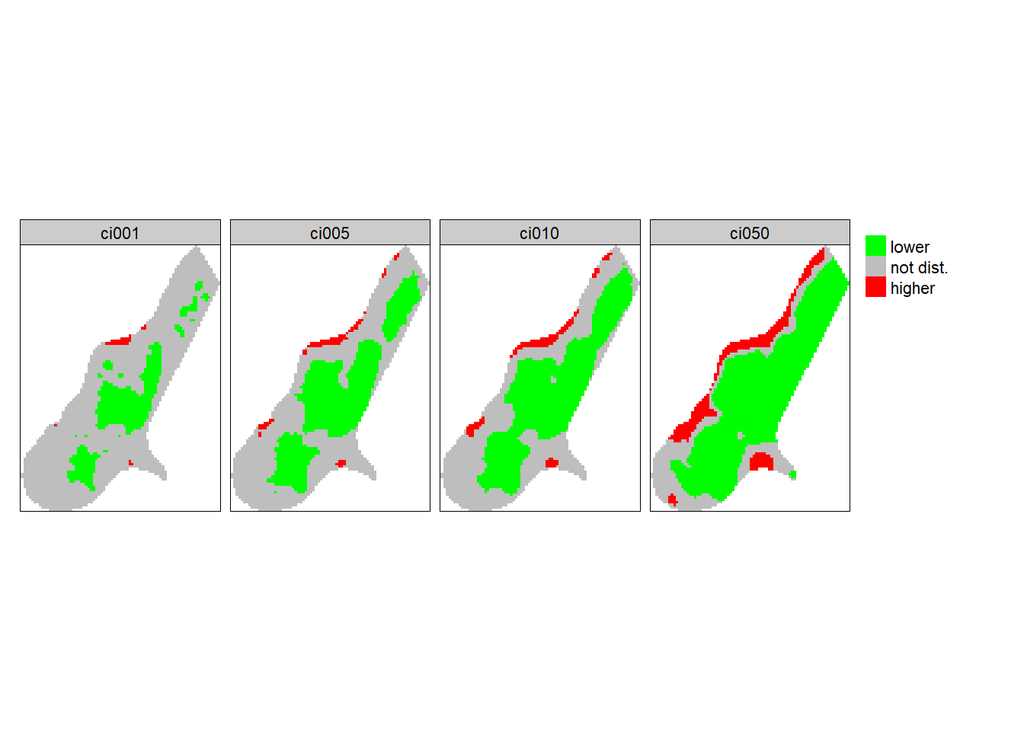

```r
lzn.ok.stars$ci001 = ci(log(500), lzn.ok.stars$var1.pred, lzn.ok.stars$var1.var, 0.01)
lzn.ok.stars$ci005 = ci(log(500), lzn.ok.stars$var1.pred, lzn.ok.stars$var1.var, 0.05)
lzn.ok.stars$ci010 = ci(log(500), lzn.ok.stars$var1.pred, lzn.ok.stars$var1.var, 0.1)
lzn.ok.stars$ci050 = ci(log(500), lzn.ok.stars$var1.pred, lzn.ok.stars$var1.var, 0.5)
tm_shape(lzn.ok.stars) +
  tm_raster(c("ci001", "ci005", "ci010", "ci050"), n=3, title = "", palette = c("green",
    "grey", "red") ) +
  tm_facets(free.scales=FALSE, nrow = 1) +
  tm_layout(legend.outside.size = 0.15, panel.labels=c("ci001", "ci005", "ci010", "ci050"))
```

#### *Exercise 7*

**Exercise 7**

*Which of these four maps has the highest confidence level, and what is this level? Why are there gray areas on map ci050 at all?*

**Solution**

The highest confidence level is 0.99 at alpha=0.01, i.e. in the map for ci001. There are grey areas in ci050 because a two-sided confidence interval is used.

Now consider the object `zn`, created under the section of block kriging.

*Hint: If you don’t have the `zn` object in your workspace, you need to reinstantiate it, by executing the complete code chunk, where the object `zn` has been created!*

**sp**

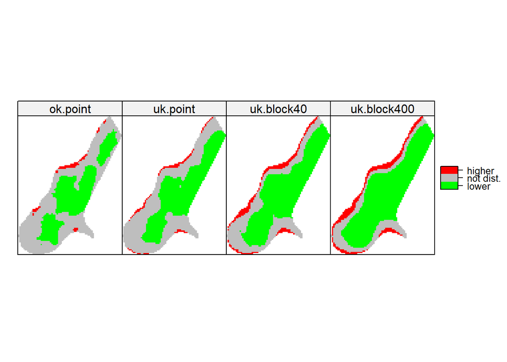

**sf/stars**

```r
v.sf = variogram(log(zinc) ~ dist, meuse.sf)
zn.res.m.sf = fit.variogram(v.sf, vgm(1, "Sph", 700, 1))
zn.stars= krige(log(zinc) ~ sqrt(dist), meuse.sf, meuse.grid.stars, zn.res.m.sf)
```

```
[using universal kriging]
```

```r
# Ordinary Kriging log(zinc)
m <- vgm(0.59, "Sph", 874, 0.04)
# ordinary kriging:
lzn.ok.stars <- krige(log(zinc) ~ 1, meuse.sf, meuse.grid.stars, model = m)
```

```
[using ordinary kriging]
```

```r
ci = function(cutoff, mean, var, alpha = 0.05) {
    p = 1 - pnorm(cutoff, mean, sqrt(var))  #$
    f = ifelse(p < alpha/2, "lower", ifelse(p < (1 - alpha/2), "not dist.",
        "higher"))
    factor(f, levels = c("lower", "not dist.", "higher"))
}

zn.stars = krige(log(zinc) ~ sqrt(dist), meuse.sf, meuse.grid.stars, zn.res.m.sf)
```

```
[using universal kriging]
```

```r
zn.stars$pointkr = zn.stars$var1.pred
zn40.stars = krige(log(zinc) ~ sqrt(dist), meuse.sf, meuse.grid.stars, zn.res.m.sf, block = c(40,
    40))
```

```
[using universal kriging]
```

```r
zn400.stars = krige(log(zinc) ~ sqrt(dist), meuse.sf, meuse.grid.stars, zn.res.m.sf, block = c(400,
    400))
```

```
[using universal kriging]
```

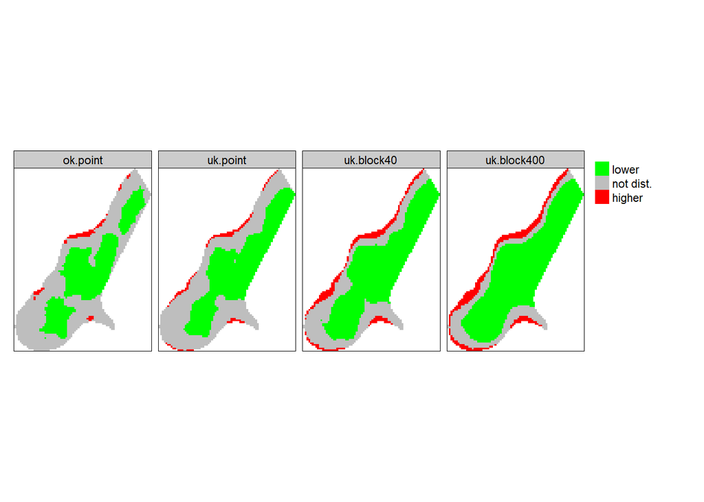

```r
zn.stars$block40 = zn40.stars$var1.pred
zn.stars$block400 = zn400.stars$var1.pred
zn.stars$pointkr.se = sqrt(zn.stars$var1.var)
zn.stars$block40.se = sqrt(zn40.stars$var1.var)
zn.stars$block400.se = sqrt(zn400.stars$var1.var)

zn.stars$ok.point = ci(log(500), lzn.ok.stars$var1.pred, lzn.ok.stars$var1.var, 0.05)
zn.stars$uk.point = ci(log(500), zn.stars$pointkr, zn.stars$pointkr.se^2, 0.05)
zn.stars$uk.block40 = ci(log(500), zn.stars$block40, zn.stars$block40.se^2, 0.05)
zn.stars$uk.block400 = ci(log(500), zn.stars$block400, zn.stars$block400.se^2, 0.05)

tm_shape(zn.stars) +
  tm_raster(c("ok.point", "uk.point", "uk.block40", "uk.block400"), n=3, title = "", palette = c("green",
    "grey", "red") ) +
  tm_facets(free.scales=FALSE, nrow = 1) +
  tm_layout(legend.outside.size = 0.15, panel.labels=c("ok.point", "uk.point", "uk.block40", "uk.block400"))
```

#### *Exercise 8*

**Exercise 8**

*Compare the fraction classified as lower and higher between ok.point and uk.point, and try to explain the difference!*

**Solution**

The proportion of grey area is smaller in UK than in OK. This means that in turn more cells are classified as lower or higher. In UK criging variances are smaller because the trend model explains some variability. This makes the confidence intervals smaller so more values are outside of them.

#### *Exercise 9*

**Exercise 9**

*Compare the fraction classified as lower and higher between uk.point uk.block40 and uk.block400, and try to explain the difference!*

**Solution**

The bigger the block the smaller the kriging variance. This lets the confidence intervals become narrower and more values are outside of them.